# R Notebook

Q1. From the dataset `heights` in the `dslabs` package, please describe the distribution of male and female heights. If you pick a female at random, what is the probability that she is 61 inches or shorter?

```r
library(dslabs)
data(heights)
library(tidyr)
library(dplyr)
library(ggplot2)
library(cowplot)
```

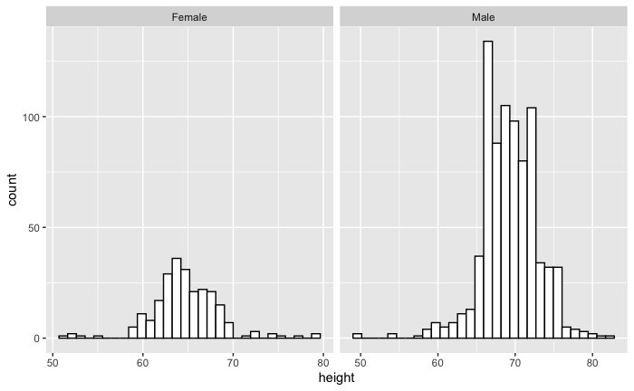

```r
p<-heights%>%
  ggplot(aes(height))+
  geom_histogram(color="black", fill="white")+
  facet_wrap(~sex, scale="free_x")
p
```

Since there are a bias in the smaple size different sex, total counts are not the same. Heights for femalse mostly are in the interval of 58 to 70, while heights for males mostly are in 60 to 76. The most counted height for female seems like is 64, but for male is 68.

```r
female<-heights%>%
  filter(sex=="Female")
ave<-mean(female$height)
s_d<-sd(female$height)
pnorm(61, ave, s_d)
```

```
[1] 0.1474261
```

Q2. For American Roulette, there are 19 reds, 16 blacks and 3 greens. The payout for winning on green is 15 dollars. You create a random variable that is the sum of your winnings after betting on green 1000 times. Start your code by setting the seed to 1. Describe your random variable (e.g. the expected value, the standard error). Then, create a Monte Carlo simulation that generates 1,000 outcomes of a random variable, and then describe your result.

```r
set.seed(1)
p<-3/(19+16+3)
N<-1000
x<-sample(c(15, -1),N, replace = T, prob = c(p, 1-p) )
X<-sum(x)
X
```

```
[1] 472
```

```r
ex<- N*(p*15+(1-p)*-1)
se<-sqrt(N)*16*sqrt(p*(1-p))
ex
```

```
[1] 263.1579
```

```r
se
```

```
[1] 136.4366
```

```r
set.seed(1)
B<-1000
N<-1000
p<-3/(19+16+3)
Z <- replicate(B,{
  x<-sample(c(15,-1), N, replace = TRUE, prob = c(p, 1-p) )
  sum(x)
})
```

```r
Z<-as_tibble(Z)
```

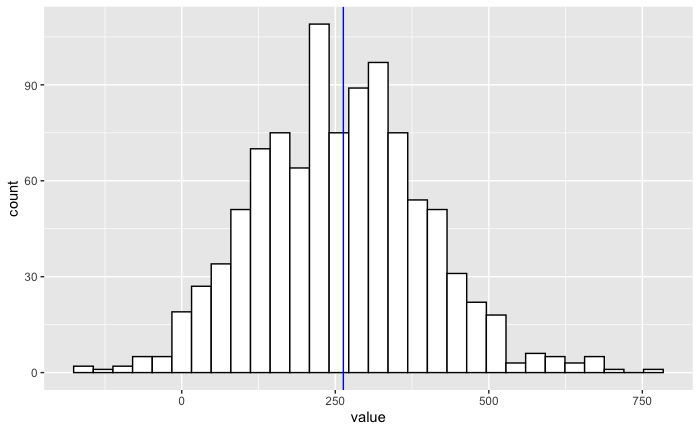

```r
Z%>%
  ggplot(aes(value))+
  geom_histogram(color="black", fill="white")+
  geom_vline(xintercept = ex, color="blue")
```

When the number of draws is large enough, the probability distribution of the standard diviation of random variables is approximately normal, which is also can be explained as Central Limit Theorem (CLT).

Q3. From the poll example, we will create a Monte Carlo simulation for p = 0.45. You will compare the sampling size (N) for 10, 1000, and the repeat size (B) for 100, 10000. So you should have four combinations (10 N x 100 B, 1000 N x 100 B, 10 N x 10000 B, 1000 N x 10000 B). Please describe your Monte Carlo simulation results, and compare four combinations.

```r
set.seed(1)
p<-0.45

cal10<-function(B, p){
  p<-0.45
  set.seed(1)
  X<-replicate(B, {
  x<-sample(c(1,0), 10, replace=T, prob=c(p, 1-p))
  x_hat<-mean(x)
  se_hat<-sqrt(x_hat*(1-x_hat)/10)
  c(x_hat, se_hat)
})}

cal1000<-function(B){
  set.seed(1)
  p<-0.45
  X<-replicate(B, {
  x<-sample(c(1,0), 1000, replace=T, prob=c(p, 1-p))
  x_hat<-mean(x)
  se_hat<-sqrt(x_hat*(1-x_hat)/1000)
  c(x_hat, se_hat)
})}
```

```r
X1<-cal10(100)
X2<-cal1000(100)
X3<-cal10(10000)
X4<-cal1000(10000)
```

```r
X1<-t(X1)
X1<-as_tibble(X1)
X1<-X1%>%
  rename(x_hat=V1, se_hat=V2)%>%
  mutate(low=x_hat-qnorm(0.975)*se_hat, high=x_hat+qnorm(0.975)*se_hat, n=seq(1:100), p_inside=ifelse(p>=low&p<=high, "Y", "N"))
X2<-t(X2)
X2<-as_tibble(X2)
X2<-X2%>%
  rename(x_hat=V1, se_hat=V2)%>%
  mutate(low=x_hat-qnorm(0.975)*se_hat, high=x_hat+qnorm(0.975)*se_hat, n=seq(1:100), p_inside=ifelse(p>=low&p<=high, "Y", "N"))
X3<-t(X3)
X3<-as_tibble(X3)
X3<-X3%>%
  rename(x_hat=V1, se_hat=V2)%>%
  mutate(low=x_hat-qnorm(0.975)*se_hat, high=x_hat+qnorm(0.975)*se_hat, n=seq(1:10000), p_inside=ifelse(p>=low&p<=high, "Y", "N"))
X4<-t(X4)
X4<-as_tibble(X4)
X4<-X4%>%
  rename(x_hat=V1, se_hat=V2)%>%
  mutate(low=x_hat-qnorm(0.975)*se_hat, high=x_hat+qnorm(0.975)*se_hat, n=seq(1:10000), p_inside=ifelse(p>=low&p<=high, "Y", "N"))
```

```r
plot1<-function(dat){
  dat%>%
    ggplot(aes(n, x_hat, color=p_inside))+
  geom_errorbar(aes(ymin=low, ymax=high))+
  geom_point(size=0.5)+
  geom_hline(yintercept=p)+
  coord_flip()+
  theme_bw()
}
plot2<-function(dat){
  dat%>%
    filter(n<101)%>%
    ggplot(aes(n, x_hat, color=p_inside))+
  geom_errorbar(aes(ymin=low, ymax=high))+
  geom_point(size=0.5)+
  geom_hline(yintercept=p)+
  coord_flip()+
  theme_bw()
}
```

```r
p1<-plot1(X1)
p2<-plot1(X2)
p3<-plot2(X3)
p4<-plot2(X4)
```

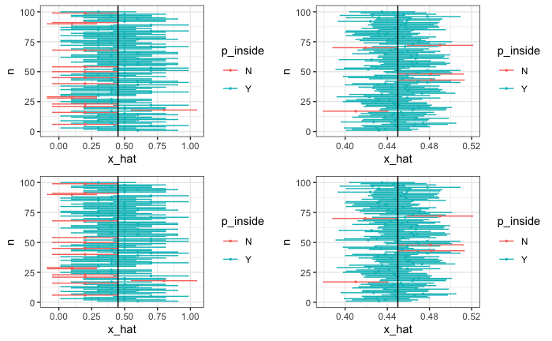

```r
plot_grid(p1, p2, p3, p4, ncol = 2)
```

In this plot, we can see 10Nx100B and 10Nx10000B has some values are not in the confidence interval, but for the plot with sample size 1000, less are not in the confidence interval. This indicates that larger samples give us more precise estimates with lower standard error and tighter confidence intervals.